# 2013 Influenza An H7N9 cases in China

## Select Best Model

We can report on the accuracy of each model by creating a list of the created models and using the summary function.

```r
#summarize accuracy of models
results <- resamples(list(cart=fit.cart, rf=fit.rf, rf=fit.rf, nb=fit.nb, bs=fit.bs))
summary(results)
```

```
##
## Call:
## summary.resamples(object = results)
##
## Models: cart, rf, rf, nb, bs
## Number of resamples: 10
##
## Accuracy
##       Min. 1st Qu. Median   Mean 3rd Qu.   Max. NA's
## rf   0.500  0.6250 0.8036 0.7353  0.8705 0.8889    0
## cart 0.500  0.5139 0.6250 0.6502  0.6920 1.0000    0
## nb   0.375  0.6250 0.6250 0.6438  0.6920 0.8750    0
## bs   0.500  0.6250 0.7321 0.6974  0.7708 0.8750    0
##
## Kappa
##          Min. 1st Qu. Median   Mean 3rd Qu.   Max. NA's
## rf   -0.06667  0.1696 0.5401 0.4394  0.7143 0.7805    0
## cart -0.23080  0.0250 0.1429 0.2258  0.3352 1.0000    0
## nb   -0.25000  0.1825 0.2500 0.2681  0.3352 0.7143    0
## bs   -0.06667  0.1696 0.4006 0.3613  0.5292 0.7143    0
```

Next, I create a plot of the model evaluation results and compare the spread and the mean accuracy of each model.

We can see that the most accurate model in this case was random forest:

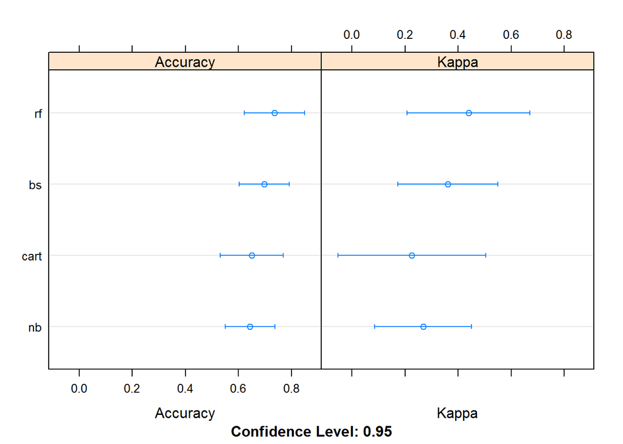

```r
# compare accuracy of models
dotplot(results)
```

The results for the random forest model can be summarized.

```r
# summarize Best Model
fit.rf$results
```

```
##   mtry  Accuracy     Kappa AccuracySD   KappaSD
## 1    2 0.7335317 0.4204260  0.1495208 0.3213362
## 2    6 0.7210317 0.4091007  0.1531715 0.3077192
## 3   11 0.7353175 0.4394341  0.1590225 0.3231133
```

This gives a nice summary of what was used to train the model and the mean and standard deviation (SD) accuracy achieved.

Let’s take a look at the confusion matrix.

```r
#confusion matrix
fit.rf$finalModel$confusion
```

```
##         Death Recover class.error
## Death      18      14   0.4375000
## Recover     7      40   0.1489362
```

Finally, we can use this model to predect test data

```r
# predict on test data
Prediction <- predict(fit.rf, test_data)

test_data$outcome <- Prediction
```

## Conclusion

This dataset does not have enough data to reliably predict the outcome. Therefore, more cases should be collected.In addiction, it is necessary to include more attributes such as medical conditions and disase parameters in order to improve accuracy.